# Estimación y supuestos del modelo clásico de regresión lineal

Oscar García Cervantes - Taller de economía cuantitativa VI

viernes 27 de mayo, 2022

# 1. Paqueterías

Para esta sesión utilizaremos las paqueterías `tidyverse`, `olsrr`, `tseries`, `broom`, `lmtest`, `car`, `lubridate`, `ggfortify`, `ggthemes`, `strucchange` y `forecast`.

```r
library(tidyverse)
library(olsrr)
library(tseries)
library(broom)
library(lmtest)
library(car)
library(lubridate)
library(ggfortify)
library(ggthemes)
library(strucchange)
library(forecast)
```

# 2. Bases de datos

Utilizaremos dos bases de datos. La primera corresponde a algunos indicadores trimestrales obtenidos del [Banco de Información Económica](https://www.inegi.org.mx/sistemas/bie/) del INEGI. La segunda incluye el PIB de Estados Unidos y se obtuvo del Federal Reserve Economic Data ([FRED](https://fred.stlouisfed.org/series/GDPC1)).

Como primer paso establecemos el directorio de trabajo con el comando `setwd()` y cargamos las bases de datos.

```r
Base1 <- read_csv("BIE.csv", col_names = TRUE)
Base2 <- read_csv("GDPC1.csv")
```

Ahora damos un vistazo a las bases.

```r
View(Base1)
View(Base2)
str(Base1)
```

```
## spec_tbl_df [112 x 16] (S3: spec_tbl_df/tbl_df/tbl/data.frame)
##  $ Periodo       : chr [1:112] "1994/01" "1994/02" "1994/03" "1994/04" ...
##  $ PIB           : num [1:112] 10436875 10656484 10737542 10861388 10238390 ...
##  $ VT_PIB        : num [1:112] 1.04 2.104 0.761 1.153 -5.736 ...
##  $ VA_PIB        : num [1:112] 3.68 5.58 5.31 5.15 -1.9 ...
##  $ Consumo_Gob   : num [1:112] 1447783 1456454 1451307 1453227 1443169 ...
##  $ Consumo_Gob_VT: num [1:112] 1.647 0.599 -0.353 0.132 -0.692 ...
##  $ Consumo_Gob_VA: num [1:112] 3.39 3.495 3.074 2.029 -0.319 ...
##  $ FBKF_Pub      : num [1:112] 492956 360344 374040 388164 412757 ...
##  $ VT_FBKF_Pub   : num [1:112] 29.65 -26.9 3.8 3.78 6.34 ...
##  $ VA_FBKF_Pub   : num [1:112] 9.9 8.13 6.07 2.09 -16.27 ...
##  $ FBKF_Priv     : num [1:112] 1973239 2130288 2132102 1993606 1302975 ...
##  $ VT_FBKF_Priv  : num [1:112] 6.1595 7.9589 0.0852 -6.4957 -34.6423 ...
##  $ VA_FBKF_Priv  : num [1:112] 17.37 22.05 19.41 7.26 -33.97 ...
##  $ Exp_ByS       : num [1:112] 1588028 1585233 1621737 1680501 1782890 ...
##  $ VT_Exp_ByS    : num [1:112] 1.99 -0.176 2.303 3.624 6.093 ...
##  $ VA_Exp_ByS    : num [1:112] 11.03 7.91 8.52 7.93 12.27 ...
##  - attr(*, "spec")=
##   .. cols(
##   ..   Periodo = col_character(),
##   ..   PIB = col_double(),
##   ..   VT_PIB = col_double(),
##   ..   VA_PIB = col_double(),
##   ..   Consumo_Gob = col_double(),
##   ..   Consumo_Gob_VT = col_double(),
##   ..   Consumo_Gob_VA = col_double(),
##   ..   FBKF_Pub = col_double(),
##   ..   VT_FBKF_Pub = col_double(),
##   ..   VA_FBKF_Pub = col_double(),
##   ..   FBKF_Priv = col_double(),
##   ..   VT_FBKF_Priv = col_double(),
##   ..   VA_FBKF_Priv = col_double(),
##   ..   Exp_ByS = col_double(),
##   ..   VT_Exp_ByS = col_double(),
##   ..   VA_Exp_ByS = col_double()
##   .. )
##  - attr(*, "problems")=<externalptr>
```

```r
str(Base2)
```

```
## spec_tbl_df [112 x 4] (S3: spec_tbl_df/tbl_df/tbl/data.frame)
##  $ DATE      : chr [1:112] "01/01/1994" "01/04/1994" "01/07/1994" "01/10/1994" ...
##  $ GDP       : num [1:112] 10195 10333 10394 10513 10550 ...
##  $ VT_GDP_EUA: num [1:112] 0.97 1.355 0.585 1.146 0.355 ...
##  $ VA_GDP_EUA: num [1:112] 3.43 4.23 4.34 4.12 3.48 ...
##  - attr(*, "spec")=
##   .. cols(
##   ..   DATE = col_character(),
##   ..   GDP = col_double(),
##   ..   VT_GDP_EUA = col_double(),
##   ..   VA_GDP_EUA = col_double()
##   .. )
##  - attr(*, "problems")=<externalptr>
```

Observamos que en ambas bases de datos tenemos la información desde 1994-1Q hasta 2021-4Q, que representan 112 observaciones. Las variables en la `Base1` son el PIB total (`PIB`), consumo del gobierno (`Consumo_Gob`), formación bruta de capital fijo pública y privada (`FBKF_Pub` y `FBKF_Priv`) y exportación de bienes y servicios (`Exp_ByS`); todas las variables están en valores absolutos, variación trimestral y variación anual. La `Base2` tiene como variable al PIB de Estados Unidos (`GDP`); los datos también están en valores absolutos, variación trimestral y variación anual.

Primero añadimos las variables de la `Base2` a la `Base1`.

```r
Base1$GDP_EUA <- Base2$GDP
Base1$VT_GDP_EUA <- Base2$VT_GDP_EUA
Base1$VA_GDP_EUA <- Base2$VA_GDP_EUA
```

Obsevamos cómo quedó la `Base1`.

```r
head(Base1, n = 6)
```

```
## # A tibble: 6 x 19
##   Periodo       PIB VT_PIB VA_PIB Consumo_Gob Consumo_Gob_VT Consumo_Gob_VA
##   <chr>       <dbl>  <dbl>  <dbl>       <dbl>          <dbl>          <dbl>
## 1 1994/01 10436875.  1.04    3.68    1447783.          1.65           3.39
## 2 1994/02 10656484.  2.10    5.58    1456454.          0.599          3.50
## 3 1994/03 10737542.  0.761   5.31    1451307.         -0.353          3.07
## 4 1994/04 10861388.  1.15    5.15    1453227.          0.132          2.03
## 5 1995/01 10238390. -5.74   -1.90    1443169.         -0.692         -0.319
## 6 1995/02  9737224. -4.89   -8.63    1432063.         -0.770         -1.67
## # ... with 12 more variables: FBKF_Pub <dbl>, VT_FBKF_Pub <dbl>,
## #   VA_FBKF_Pub <dbl>, FBKF_Priv <dbl>, VT_FBKF_Priv <dbl>, VA_FBKF_Priv <dbl>,
## #   Exp_ByS <dbl>, VT_Exp_ByS <dbl>, VA_Exp_ByS <dbl>, GDP_EUA <dbl>,
## #   VT_GDP_EUA <dbl>, VA_GDP_EUA <dbl>
```

Un aspecto importante es que para ambas bases la variable que determina el periodo es de tipo (clase) texto. Necesitamos cambiar el formato de `Periodo` para poder visualizar de manera correcta los valores.

```r
Base1$Periodo <- yq(Base1$Periodo)
str(Base1)
```

```
## spec_tbl_df [112 x 19] (S3: spec_tbl_df/tbl_df/tbl/data.frame)
##  $ Periodo       : Date[1:112], format: "1994-01-01" "1994-04-01" ...
##  $ PIB           : num [1:112] 10436875 10656484 10737542 10861388 10238390 ...
##  $ VT_PIB        : num [1:112] 1.04 2.104 0.761 1.153 -5.736 ...
##  $ VA_PIB        : num [1:112] 3.68 5.58 5.31 5.15 -1.9 ...
##  $ Consumo_Gob   : num [1:112] 1447783 1456454 1451307 1453227 1443169 ...
##  $ Consumo_Gob_VT: num [1:112] 1.647 0.599 -0.353 0.132 -0.692 ...
##  $ Consumo_Gob_VA: num [1:112] 3.39 3.495 3.074 2.029 -0.319 ...
##  $ FBKF_Pub      : num [1:112] 492956 360344 374040 388164 412757 ...
##  $ VT_FBKF_Pub   : num [1:112] 29.65 -26.9 3.8 3.78 6.34 ...
##  $ VA_FBKF_Pub   : num [1:112] 9.9 8.13 6.07 2.09 -16.27 ...
##  $ FBKF_Priv     : num [1:112] 1973239 2130288 2132102 1993606 1302975 ...
##  $ VT_FBKF_Priv  : num [1:112] 6.1595 7.9589 0.0852 -6.4957 -34.6423 ...
##  $ VA_FBKF_Priv  : num [1:112] 17.37 22.05 19.41 7.26 -33.97 ...
##  $ Exp_ByS       : num [1:112] 1588028 1585233 1621737 1680501 1782890 ...
##  $ VT_Exp_ByS    : num [1:112] 1.99 -0.176 2.303 3.624 6.093 ...
##  $ VA_Exp_ByS    : num [1:112] 11.03 7.91 8.52 7.93 12.27 ...
##  $ GDP_EUA       : num [1:112] 10195 10333 10394 10513 10550 ...
##  $ VT_GDP_EUA    : num [1:112] 0.97 1.355 0.585 1.146 0.355 ...
##  $ VA_GDP_EUA    : num [1:112] 3.43 4.23 4.34 4.12 3.48 ...
##  - attr(*, "spec")=
##   .. cols(
##   ..   Periodo = col_character(),
##   ..   PIB = col_double(),
##   ..   VT_PIB = col_double(),
##   ..   VA_PIB = col_double(),
##   ..   Consumo_Gob = col_double(),
##   ..   Consumo_Gob_VT = col_double(),
##   ..   Consumo_Gob_VA = col_double(),
##   ..   FBKF_Pub = col_double(),
##   ..   VT_FBKF_Pub = col_double(),
##   ..   VA_FBKF_Pub = col_double(),
##   ..   FBKF_Priv = col_double(),
##   ..   VT_FBKF_Priv = col_double(),
##   ..   VA_FBKF_Priv = col_double(),
##   ..   Exp_ByS = col_double(),
##   ..   VT_Exp_ByS = col_double(),
##   ..   VA_Exp_ByS = col_double()
##   .. )
##  - attr(*, "problems")=<externalptr>
```

# 3. Visualización de datos

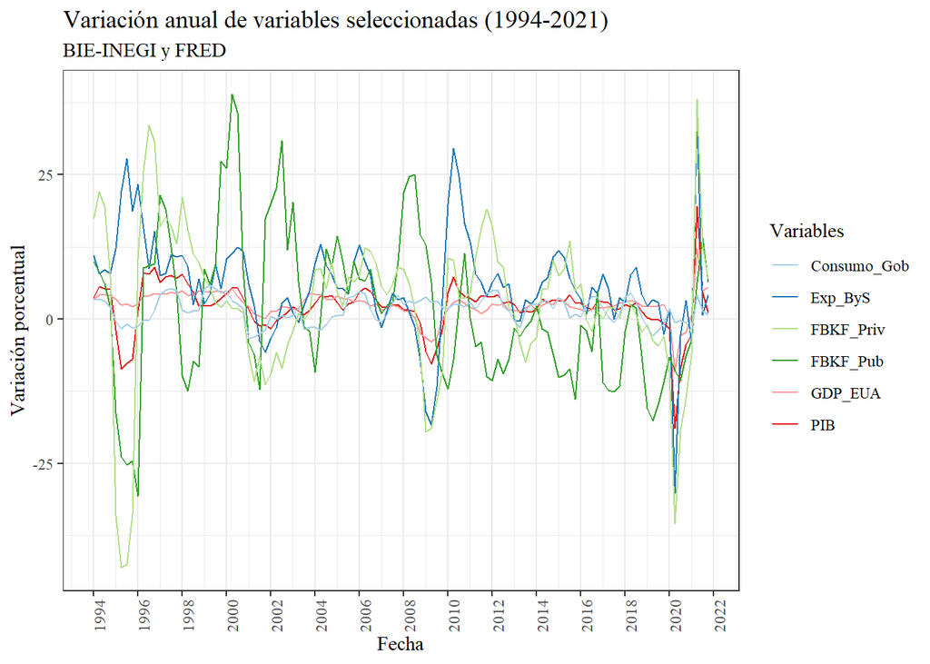

```r
ggplot(Base1, aes(x = Periodo)) +
     geom_line(aes(y = VA_PIB, color = "PIB")) +
     geom_line(aes(y = VA_GDP_EUA, color = "GDP_EUA")) +
     geom_line(aes(y = VA_Exp_ByS, color = "Exp_ByS")) +
     geom_line(aes(y = VA_FBKF_Pub, color = "FBKF_Pub")) +
     geom_line(aes(y = VA_FBKF_Priv, color = "FBKF_Priv")) +
     geom_line(aes(y = Consumo_Gob_VA, color = "Consumo_Gob")) +
     labs(title = "Variación anual de variables seleccionadas (1994-2021)",
          subtitle = "BIE-INEGI y FRED",
          x = "Fecha",
          y = "Variación porcentual",
          colour = "Variables") +
     theme_bw(base_family = "serif") +
     scale_x_date(date_breaks = "2 year", date_labels = "%Y") +
     theme(axis.text.x = element_text(angle = 90)) +
     scale_color_brewer(palette = "Paired")
```

Ahora visualizamos de manera individual el **PIB** que será nuestra variable dependiente.

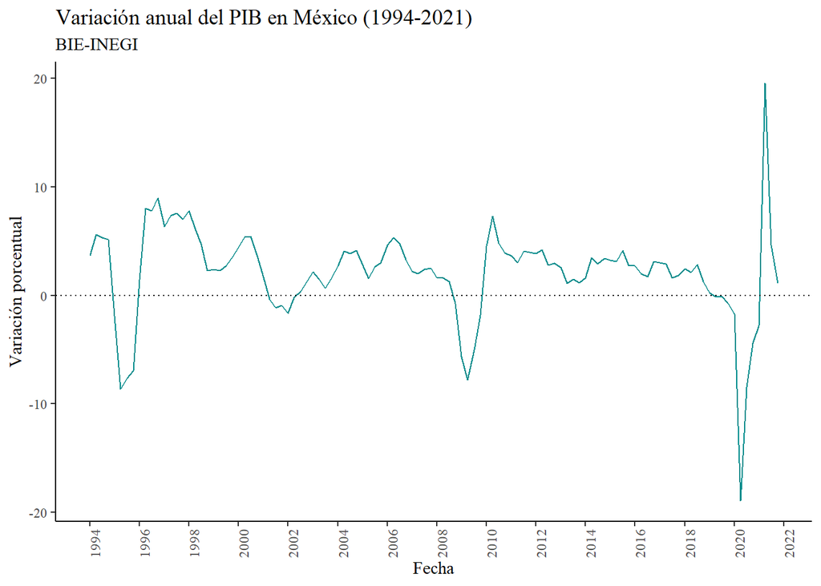

# 4. Regresión lineal

El primer modelo que estimaremos mediante el método de MCO será con las variables en valores absolutos. El segundo modelo utilizará las variaciones anuales. El tercer modelo será un log-lineal. Por último se estimará un modelo log-log con los valores absolutos.

## 4.1 Significancia de los coeficientes y sentido económico

```r
m1 <- lm(PIB ~ Consumo_Gob + FBKF_Pub + FBKF_Priv + Exp_ByS + GDP_EUA, data = Base1)
m2 <- lm(VA_PIB ~ Consumo_Gob_VA + VA_FBKF_Pub + VA_FBKF_Priv + VA_Exp_ByS + VA_GDP_EUA, data = Base1)
m3 <- lm(log(PIB) ~ Consumo_Gob + FBKF_Pub + FBKF_Priv + Exp_ByS + GDP_EUA, data = Base1)
m4 <- lm(log(PIB) ~ log(Consumo_Gob) + log(FBKF_Pub) + log(FBKF_Priv) + log(Exp_ByS) + log(GDP_EUA), data = Base1)
tidy(m1)
```

```
## # A tibble: 6 x 5
##   term           estimate   std.error statistic  p.value
##   <chr>             <dbl>       <dbl>     <dbl>    <dbl>
## 1 (Intercept) 3043531.    446807.         6.81  6.04e-10
## 2 Consumo_Gob       0.121      0.279      0.434 6.65e- 1
## 3 FBKF_Pub          0.699      0.142      4.92  3.12e- 6
## 4 FBKF_Priv         1.30       0.0726    17.9   8.27e-34
## 5 Exp_ByS           0.564      0.0806     7.00  2.38e-10
## 6 GDP_EUA         361.        38.3        9.41  1.18e-15
```

```r
tidy(m2)
```

```
## # A tibble: 6 x 5
##   term           estimate std.error statistic  p.value
##   <chr>             <dbl>     <dbl>     <dbl>    <dbl>
## 1 (Intercept)     -0.299     0.213     -1.40  1.63e- 1
## 2 Consumo_Gob_VA   0.0307    0.0635     0.483 6.30e- 1
## 3 VA_FBKF_Pub      0.0362    0.0110     3.30  1.32e- 3
## 4 VA_FBKF_Priv     0.199     0.0122    16.3   1.27e-30
## 5 VA_Exp_ByS       0.0942    0.0219     4.30  3.81e- 5
## 6 VA_GDP_EUA       0.504     0.0930     5.42  3.80e- 7
```

```r
tidy(m3)
```

```
## # A tibble: 6 x 5
##   term             estimate     std.error statistic   p.value
##   <chr>               <dbl>         <dbl>     <dbl>     <dbl>
## 1 (Intercept) 15.5          0.0423          367.    2.27e-166
## 2 Consumo_Gob -0.0000000163 0.0000000265     -0.616 5.40e-  1
## 3 FBKF_Pub     0.0000000691 0.0000000134      5.14  1.28e-  6
## 4 FBKF_Priv    0.000000100  0.00000000688    14.5   5.17e- 27
## 5 Exp_ByS      0.0000000114 0.00000000763     1.49  1.39e-  1
## 6 GDP_EUA      0.0000427    0.00000363       11.7   6.83e- 21
```

```r
tidy(m4)
```

```
## # A tibble: 6 x 5
##   term             estimate std.error statistic  p.value
##   <chr>               <dbl>     <dbl>     <dbl>    <dbl>
## 1 (Intercept)        6.18     0.263       23.5  8.30e-44
## 2 log(Consumo_Gob)   0.115    0.0282       4.07 9.14e- 5
## 3 log(FBKF_Pub)      0.0155   0.00456      3.39 9.88e- 4
## 4 log(FBKF_Priv)     0.196    0.00991     19.8  1.81e-37
## 5 log(Exp_ByS)       0.131    0.0195       6.72 9.61e-10
## 6 log(GDP_EUA)       0.372    0.0415       8.98 1.12e-14
```

Despues de evaluar la significancia estadística de las variables estimaremos los modelos `m1` y `m2` sin la variable `Consumo_Gob`.

```r
m1_2 <- lm(PIB ~ FBKF_Pub + FBKF_Priv + Exp_ByS + GDP_EUA, data = Base1)
m2_2 <- lm(VA_PIB ~ VA_FBKF_Pub + VA_FBKF_Priv + VA_Exp_ByS + VA_GDP_EUA, data = Base1)
tidy(m1_2)
```

```
## # A tibble: 5 x 5
##   term           estimate   std.error statistic  p.value
##   <chr>             <dbl>       <dbl>     <dbl>    <dbl>
## 1 (Intercept) 3181161.    313423.         10.1  2.33e-17
## 2 FBKF_Pub          0.709      0.139       5.08 1.59e- 6
## 3 FBKF_Priv         1.30       0.0713     18.3  1.09e-34
## 4 Exp_ByS           0.583      0.0668      8.73 3.74e-14
## 5 GDP_EUA         360.        38.1         9.44 9.31e-16
```

```r
tidy(m2_2)
```

```
## # A tibble: 5 x 5
##   term         estimate std.error statistic  p.value
##   <chr>           <dbl>     <dbl>     <dbl>    <dbl>
## 1 (Intercept)   -0.253     0.190      -1.33 1.85e- 1
## 2 VA_FBKF_Pub    0.0380    0.0103      3.71 3.32e- 4
## 3 VA_FBKF_Priv   0.201     0.0116     17.3  1.06e-32
## 4 VA_Exp_ByS     0.0957    0.0216      4.42 2.35e- 5
## 5 VA_GDP_EUA     0.499     0.0921      5.42 3.75e- 7
```

De los modelos estimados observamos que la variable que muestra una mayor relación con el PIB mexicano es el PIB de Estados Unidos. Podemos observar esta relación si graficamos unicamente las dos series.

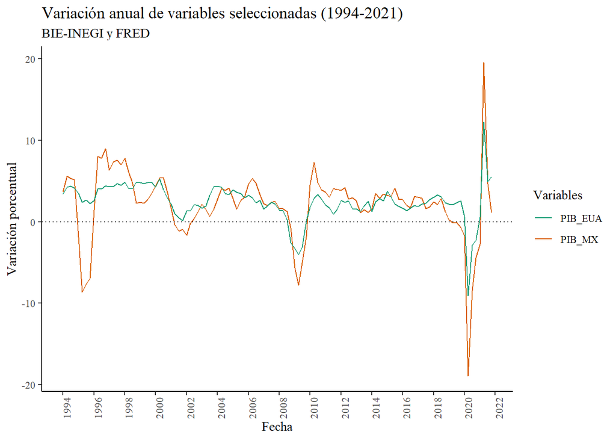

## 4.2 Bondad de ajuste de los modelos

De aquí en adelante trabajaremos unicamente con los modelos `m1_2`, `m2_2` y `m4`. Obtenemos la $R^2$, la $R^2 ajd$ y el estadístico $F$.

```r
glance(m1_2)
```

```
## # A tibble: 1 x 12
##   r.squared adj.r.squared   sigma statistic   p.value    df logLik   AIC   BIC
##       <dbl>         <dbl>   <dbl>     <dbl>     <dbl> <dbl>  <dbl> <dbl> <dbl>
## 1     0.996         0.996 156465.     7150. 6.35e-129     4 -1496. 3004. 3020.
## # ... with 3 more variables: deviance <dbl>, df.residual <int>, nobs <int>
```

```r
glance(m2_2)
```

```
## # A tibble: 1 x 12
##   r.squared adj.r.squared sigma statistic  p.value    df logLik   AIC   BIC
##       <dbl>         <dbl> <dbl>     <dbl>    <dbl> <dbl>  <dbl> <dbl> <dbl>
## 1     0.913         0.910  1.28      282. 7.01e-56     4  -184.  380.  396.
## # ... with 3 more variables: deviance <dbl>, df.residual <int>, nobs <int>
```

```r
glance(m4)
```

```
## # A tibble: 1 x 12
##   r.squared adj.r.squared  sigma statistic   p.value    df logLik   AIC   BIC
##       <dbl>         <dbl>  <dbl>     <dbl>     <dbl> <dbl>  <dbl> <dbl> <dbl>
## 1     0.997         0.996 0.0106     6175. 6.14e-129     5   353. -693. -674.
## # ... with 3 more variables: deviance <dbl>, df.residual <int>, nobs <int>
```

Todos los modelos muestran $R^2$ y $R^2 adj$ superiores al **0.9**. Además, rechazamos la hipótesis nula de la Prueba F donde $H_0:\beta_1=\beta_2=\beta_k=0$, es decir, rechazamos que las variables del modelo sean simultaneamente nulas.

# 5. Supuesto de normalidad

Una vez estimado el modelo y habiendo analizado el sentido económico de las variables independientes, llevamos a cabo pruebas de correcta especificación. La primera prueba es la de normalidad.

Podemos visualizar los errores para ver su comportamiento y analizar si se distribuyen como una normal.

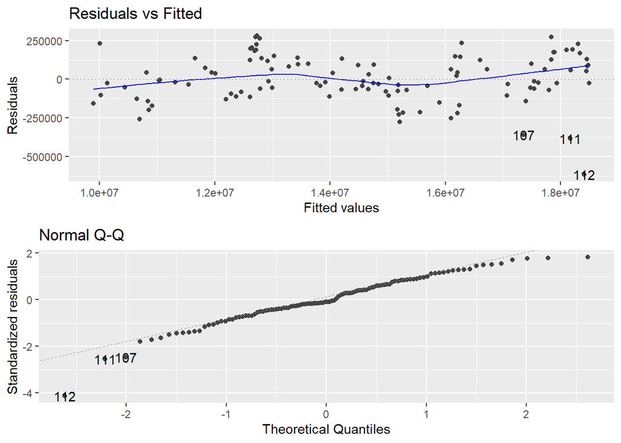

```r
autoplot(m1_2, which = 1:2, nrow =2, ncol = 1)
```

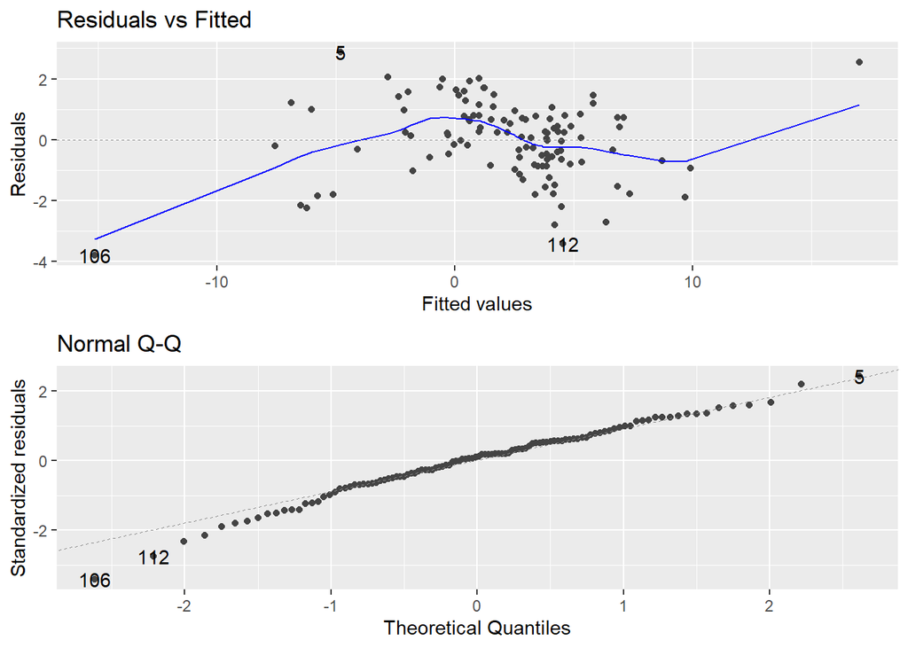

```r
autoplot(m2_2, which = 1:2, nrow =2, ncol = 1)
```

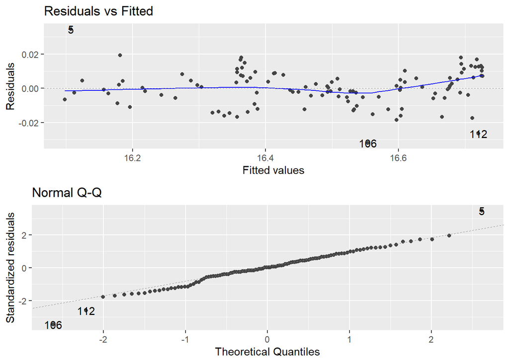

```r
autoplot(m4, which = 1:2, nrow =2, ncol = 1)
```

Para comprobar el supuesto de normalidad utilizamos la prueba Jarque-Bera. La hipótesis nula de esta prueba es que los errores se distribuyen como una normal, $H_0: Errores\ normales$ o $H_0:s=0,c=3$.

```r
jarque.bera.test(m1_2$residuals)
```

```
##
##  Jarque Bera Test
##
## data:  m1_2$residuals
## X-squared = 16.795, df = 2, p-value = 0.0002254
```

```r
jarque.bera.test(m2_2$residuals)
```

```
##
##  Jarque Bera Test
##
## data:  m2_2$residuals
## X-squared = 3.9972, df = 2, p-value = 0.1355
```

```r
jarque.bera.test(m4$residuals)
```

```
##
##  Jarque Bera Test
##
## data:  m4$residuals
## X-squared = 2.5153, df = 2, p-value = 0.2843
```

Los resultados de la prueba Jarque-Bera nos indican que para los modelos `m2_2` y `m4` no rechazamos la hipótesis nula, es decir, los errores se distribuyen como una normal, mientras que en el modelo `m1_2` al tener un $p\ value < 0.05$ rechazamos la hipótesis nula y aceptamos la hipótesis alternativa de no normalidad en los errores.

Una ventaja de graficar los errores, es que nos indica qué observaciones son outliers y podemos generar variables ficticias para esas observaciones.

# 6. Supuesto de homocedasticidad

Para revisar si los errores de nuestros modelos tienen varianza constantes, es decir, si son homocedasticos utilizamos la prueba de [Breusch-Pagan](https://cran.r-project.org/web/packages/olsrr/vignettes/heteroskedasticity.html#:~:text=Breusch%20Pagan%20Test,-Breusch%20Pagan%20Test&text=It%20is%20used%20to%20test,is%20a%20%CF%872%20test.). El test asume que los errores se distribuyen como una normal. La hipótesis nula es que los errores son homocedasticos, $H_0:varianza\ constante$.

```r
ols_test_breusch_pagan(m1_2)
```

```
##
##  Breusch Pagan Test for Heteroskedasticity
##  -----------------------------------------
##  Ho: the variance is constant
##  Ha: the variance is not constant
##
##              Data
##  -------------------------------
##  Response : PIB
##  Variables: fitted values of PIB
##
##         Test Summary
##  -----------------------------
##  DF            =    1
##  Chi2          =    5.222962
##  Prob > Chi2   =    0.02229056
```

```r
ols_test_breusch_pagan(m2_2)
```

```
##
##  Breusch Pagan Test for Heteroskedasticity
##  -----------------------------------------
##  Ho: the variance is constant
##  Ha: the variance is not constant
##
##                Data
##  ----------------------------------
##  Response : VA_PIB
##  Variables: fitted values of VA_PIB
##
##          Test Summary
##  ------------------------------
##  DF            =    1
##  Chi2          =    7.095105
##  Prob > Chi2   =    0.007729476
```

```r
ols_test_breusch_pagan(m4)
```

```
##
##  Breusch Pagan Test for Heteroskedasticity
##  -----------------------------------------
##  Ho: the variance is constant
##  Ha: the variance is not constant
##
##                 Data
##  ------------------------------------
##  Response : log(PIB)
##  Variables: fitted values of log(PIB)
##
##         Test Summary
##  ----------------------------
##  DF            =    1
##  Chi2          =    0.0151574
##  Prob > Chi2   =    0.9020157
```

En los modelos `m1_2` y `m2_2` rechazamos la hipótesis nula de varianza constante de los errores, es decir, existe heterocedasticidad. Mientras que para el modelo `m4` no se rechaza la hipóesis nula, por lo que para esta estimación los errores tienen varianza constante.

# 7 Supuesto de multicolinealidad

Para probar la existencia de multicolinealidad primero observamos la correlaciones entre las variables independientes. Como primer paso extraemos las variables independientes en una base para después generar una matriz de correlaciones.

```r
Variables_ind <- Base1 %>%
        select(FBKF_Pub, FBKF_Priv, Exp_ByS, GDP_EUA)
cor(Variables_ind)
```

```
##            FBKF_Pub FBKF_Priv   Exp_ByS   GDP_EUA
## FBKF_Pub  1.0000000 0.4132408 0.3229642 0.4578447
## FBKF_Priv 0.4132408 1.0000000 0.8956026 0.8739528
## Exp_ByS   0.3229642 0.8956026 1.0000000 0.9759422
## GDP_EUA   0.4578447 0.8739528 0.9759422 1.0000000
```

Observamos que existe un fuerte correlación positiva entre las variables `FBKF_Priv`, `Exp_ByS` y `GDP_EUA`.

Ahora realizamos la prueba de multicolinealidad del Factor de inflación de la varianza (VIF).

```r
vif(m1_2)
```

```
##  FBKF_Pub FBKF_Priv   Exp_ByS   GDP_EUA
##  2.567096  6.065998 50.898143 44.174131
```

```r
vif(m2_2)
```

```
##  VA_FBKF_Pub VA_FBKF_Priv   VA_Exp_ByS   VA_GDP_EUA
##     1.212462     1.637274     2.335876     3.045143
```

```r
vif(m4)
```

```
## log(Consumo_Gob)    log(FBKF_Pub)   log(FBKF_Priv)     log(Exp_ByS)
##        15.772233         2.119119         4.970416        59.242170
##     log(GDP_EUA)
##        54.176975
```

La regla sobre el VIF es que existe multicolinealidad si el promedio de todos los valores es mayor a 10 o el mayor tiene un valor superior a 10. Los modelos `m1_2` y `m4` muestran multicolinealidad, las variables con valores más altos son son las exportaciones de bienes y servicios `Exp_ByS` y el PIB de Estados Unidos `GDP_EUA`. Esto se explica porque las exportaciones de la economía mexicana se concentran altamente en la economía estadounidense.

Una de las formas para solucionar el problema de multicolinealidad es transformar las variables, esta es una de las posibles razones por las que el modelo `m2_2` no muestra multicolinealidad, ya que los valores son las tasas de crecimiento de las variables utilizadas en el modelo `m1_2`.

# 8. Supuesto de cambio estructural

Para probar si existe cambio estructural utilizamos el test de Chow.

```r
sctest(m1_2, type = "Chow")
```

```
##
##  M-fluctuation test
##
## data:  m1_2
## f(efp) = 2.1792, p-value = 0.0007501
```

```r
sctest(m2_2, type = "Chow")
```

```
##
##  M-fluctuation test
##
## data:  m2_2
## f(efp) = 1.4623, p-value = 0.1314
```

```r
sctest(m4, type = "Chow")
```

```
##
##  M-fluctuation test
##
## data:  m4
## f(efp) = 2.1682, p-value = 0.00099
```

Los modelos `m1_2` y `m4` presenta cambio estructural al presentar un $p-value < 0.05$. Para el modelo `m2_2` no rechazamos la hipótesis nula $H_0:\beta_1=\beta_2$.

# 9. Soluciones al incumplimiento de los supuestos del MCRL

Como primer paso, generamos un variable dummy para suavizar la caida de las variables ocasionada por el confinamiento derivado de la pandemia de la COVID-19 en el segundo trimestre de 2020.

```r
Base1 <- Base1 %>%
     mutate(ficticia1 = ifelse(VA_PIB < -15, 1, 0))
```

Como segundo paso, estimamos los modelos `m1_2` y `m4` sin la variable `Exp_ByS` para solucionar la multicolinealidad; además agregamos la variable dummy en los modelos.

```r
m1_3 <- lm(PIB ~ FBKF_Pub + FBKF_Priv + GDP_EUA + ficticia1, data = Base1)
m2_3 <- lm(VA_PIB ~ VA_FBKF_Pub + VA_FBKF_Priv + VA_Exp_ByS + VA_GDP_EUA + ficticia1, data = Base1)
m4_2 <- lm(log(PIB) ~ log(Consumo_Gob) + log(FBKF_Pub) + log(FBKF_Priv) + log(GDP_EUA) + ficticia1, data = Base1)

summary(m1_3)
```

```
##
## Call:
## lm(formula = PIB ~ FBKF_Pub + FBKF_Priv + GDP_EUA + ficticia1,
##     data = Base1)
##
## Residuals:
##     Min      1Q  Median      3Q     Max
## -713706 -137266   33388  151530  462399
##
## Coefficients:
##               Estimate Std. Error t value Pr(>|t|)
## (Intercept)  5.316e+05  1.141e+05   4.659  9.2e-06 ***
## FBKF_Pub    -1.983e-01  1.254e-01  -1.581   0.1169
## FBKF_Priv    1.587e+00  7.915e-02  20.051  < 2e-16 ***
## GDP_EUA      6.880e+02  1.617e+01  42.555  < 2e-16 ***
## ficticia1   -5.377e+05  2.111e+05  -2.547   0.0123 *
## ---
## Signif. codes:  0 '***' 0.001 '**' 0.01 '*' 0.05 '.' 0.1 ' ' 1
##
## Residual standard error: 198800 on 107 degrees of freedom
## Multiple R-squared:  0.994,  Adjusted R-squared:  0.9938
## F-statistic:  4419 on 4 and 107 DF,  p-value: < 2.2e-16
```

```r
summary(m2_3)
```

```
##
## Call:
## lm(formula = VA_PIB ~ VA_FBKF_Pub + VA_FBKF_Priv + VA_Exp_ByS +
##     VA_GDP_EUA + ficticia1, data = Base1)
##
## Residuals:
##     Min      1Q  Median      3Q     Max
## -3.2266 -0.7452  0.0786  0.7290  3.4824
##
## Coefficients:
##               Estimate Std. Error t value Pr(>|t|)
## (Intercept)   0.029928   0.196240   0.153 0.879079
## VA_FBKF_Pub   0.036730   0.009733   3.774 0.000265 ***
## VA_FBKF_Priv  0.201138   0.011031  18.234  < 2e-16 ***
## VA_Exp_ByS    0.087692   0.020624   4.252 4.58e-05 ***
## VA_GDP_EUA    0.421061   0.089892   4.684 8.38e-06 ***
## ficticia1    -5.030966   1.393225  -3.611 0.000468 ***
## ---
## Signif. codes:  0 '***' 0.001 '**' 0.01 '*' 0.05 '.' 0.1 ' ' 1
##
## Residual standard error: 1.211 on 106 degrees of freedom
## Multiple R-squared:  0.9229, Adjusted R-squared:  0.9193
## F-statistic: 253.8 on 5 and 106 DF,  p-value: < 2.2e-16
```

```r
summary(m4_2)
```

```
##
## Call:
## lm(formula = log(PIB) ~ log(Consumo_Gob) + log(FBKF_Pub) + log(FBKF_Priv) +
##     log(GDP_EUA) + ficticia1, data = Base1)
##
## Residuals:
##       Min        1Q    Median        3Q       Max
## -0.037985 -0.006799  0.001911  0.007653  0.024573
##
## Coefficients:
##                   Estimate Std. Error t value Pr(>|t|)
## (Intercept)       4.740439   0.208280  22.760  < 2e-16 ***
## log(Consumo_Gob)  0.215602   0.029537   7.299 5.56e-11 ***
## log(FBKF_Pub)     0.002579   0.004485   0.575    0.566
## log(FBKF_Priv)    0.187690   0.011191  16.771  < 2e-16 ***
## log(GDP_EUA)      0.609122   0.022304  27.310  < 2e-16 ***
## ficticia1        -0.062041   0.012432  -4.990 2.37e-06 ***
## ---
## Signif. codes:  0 '***' 0.001 '**' 0.01 '*' 0.05 '.' 0.1 ' ' 1
##
## Residual standard error: 0.01139 on 106 degrees of freedom
## Multiple R-squared:  0.9961, Adjusted R-squared:  0.9959
## F-statistic:  5347 on 5 and 106 DF,  p-value: < 2.2e-16
```

En esta nueva especificación la variable `FBKF_Pub` dejó de ser significativa en los modelos `m1_3` y `m4_2`. Generamos una nueva estimación sin esta variable.

```r
m1_4 <- lm(PIB ~ FBKF_Priv + GDP_EUA + ficticia1, data = Base1)
m4_3 <- lm(log(PIB) ~ log(Consumo_Gob) + log(FBKF_Priv) + log(GDP_EUA) + ficticia1, data = Base1)

summary(m1_4)
```

```
##
## Call:
## lm(formula = PIB ~ FBKF_Priv + GDP_EUA + ficticia1, data = Base1)
##
## Residuals:
##     Min      1Q  Median      3Q     Max
## -661753 -141076   30837  149431  464992
##
## Coefficients:
##               Estimate Std. Error t value Pr(>|t|)
## (Intercept)  5.120e+05  1.142e+05   4.483 1.84e-05 ***
## FBKF_Priv    1.588e+00  7.969e-02  19.927  < 2e-16 ***
## GDP_EUA      6.817e+02  1.578e+01  43.199  < 2e-16 ***
## ficticia1   -4.954e+05  2.109e+05  -2.349   0.0206 *
## ---
## Signif. codes:  0 '***' 0.001 '**' 0.01 '*' 0.05 '.' 0.1 ' ' 1
##
## Residual standard error: 200200 on 108 degrees of freedom
## Multiple R-squared:  0.9938, Adjusted R-squared:  0.9937
## F-statistic:  5810 on 3 and 108 DF,  p-value: < 2.2e-16
```

```r
summary(m4_3)
```

```
##
## Call:
## lm(formula = log(PIB) ~ log(Consumo_Gob) + log(FBKF_Priv) + log(GDP_EUA) +
##     ficticia1, data = Base1)
##
## Residuals:
##       Min        1Q    Median        3Q       Max
## -0.039168 -0.006029  0.001928  0.007680  0.025376
##
## Coefficients:
##                  Estimate Std. Error t value Pr(>|t|)
## (Intercept)       4.78892    0.18985  25.224  < 2e-16 ***
## log(Consumo_Gob)  0.20926    0.02731   7.661 8.78e-12 ***
## log(FBKF_Priv)    0.18893    0.01095  17.260  < 2e-16 ***
## log(GDP_EUA)      0.61523    0.01956  31.460  < 2e-16 ***
## ficticia1        -0.06221    0.01239  -5.021 2.06e-06 ***
## ---
## Signif. codes:  0 '***' 0.001 '**' 0.01 '*' 0.05 '.' 0.1 ' ' 1
##
## Residual standard error: 0.01136 on 107 degrees of freedom
## Multiple R-squared:  0.996,  Adjusted R-squared:  0.9959
## F-statistic:  6726 on 4 and 107 DF,  p-value: < 2.2e-16
```

Nuevamente realizamos las pruebas de normalidad, de homocedasticidad, multicolinealidad y de cambio estructural a los modelos `m1_4`, `m2_3` y `m4_3`.

```r
jarque.bera.test(m1_4$residuals)
```

```
##
##  Jarque Bera Test
##
## data:  m1_4$residuals
## X-squared = 5.6494, df = 2, p-value = 0.05933
```

```r
ols_test_breusch_pagan(m1_4)
```

```
##
##  Breusch Pagan Test for Heteroskedasticity
##  -----------------------------------------
##  Ho: the variance is constant
##  Ha: the variance is not constant
##
##              Data
##  -------------------------------
##  Response : PIB
##  Variables: fitted values of PIB
##
##         Test Summary
##  ----------------------------
##  DF            =    1
##  Chi2          =    2.471061
##  Prob > Chi2   =    0.1159596
```

```r
vif(m1_4)
```

```
## FBKF_Priv   GDP_EUA ficticia1
##  4.626424  4.631468  1.099683
```

```r
sctest(m1_4, type = "Chow")
```

```
##
##  M-fluctuation test
##
## data:  m1_4
## f(efp) = 2.5723, p-value = 1.432e-05
```

```r
jarque.bera.test(m2_3$residuals)
```

```
##
##  Jarque Bera Test
##
## data:  m2_3$residuals
## X-squared = 0.95852, df = 2, p-value = 0.6192
```

```r
ols_test_breusch_pagan(m2_3)
```

```
##
##  Breusch Pagan Test for Heteroskedasticity
##  -----------------------------------------
##  Ho: the variance is constant
##  Ha: the variance is not constant
##
##                Data
##  ----------------------------------
##  Response : VA_PIB
##  Variables: fitted values of VA_PIB
##
##         Test Summary
##  ----------------------------
##  DF            =    1
##  Chi2          =    0.6987832
##  Prob > Chi2   =    0.4031929
```

```r
vif(m2_3)
```

```
##  VA_FBKF_Pub VA_FBKF_Priv   VA_Exp_ByS   VA_GDP_EUA    ficticia1
##     1.214168     1.637367     2.362938     3.230163     1.311890
```

```r
sctest(m2_3, type = "Chow")
```

```
##
##  M-fluctuation test
##
## data:  m2_3
## f(efp) = 1.3579, p-value = 0.2651
```

```r
jarque.bera.test(m4_3$residuals)
```

```
##
##  Jarque Bera Test
##
## data:  m4_3$residuals
## X-squared = 18.727, df = 2, p-value = 8.578e-05
```

```r
ols_test_breusch_pagan(m4_3)
```

```
##
##  Breusch Pagan Test for Heteroskedasticity
##  -----------------------------------------
##  Ho: the variance is constant
##  Ha: the variance is not constant
##
##                 Data
##  ------------------------------------
##  Response : log(PIB)
##  Variables: fitted values of log(PIB)
##
##         Test Summary
##  ----------------------------
##  DF            =    1
##  Chi2          =    1.499329
##  Prob > Chi2   =    0.2207747
```

```r
vif(m4_3)
```

```
## log(Consumo_Gob)   log(FBKF_Priv)     log(GDP_EUA)        ficticia1
##        12.929779         5.291976        10.495254         1.179205
```

```r
sctest(m4_3, type = "Chow")
```

```
##
##  M-fluctuation test
##
## data:  m4_3
## f(efp) = 2.1899, p-value = 0.0006829
```

Los modelos `m1_4` y `m2_3` cumplen con los supuestos de normalidad, homocedasticiad y de no multicolinealidad. Mientras que la nueva estimación del modelo `m4_3`, no cumple con los supuestos de normalidad y sigue mostrando multicolinealidad. Respecto al supuesto de cambio estructural el único modelo que no presenta cambio estructural es el `m2_3` esto porque los valores son tasas de crecimiento y los datos atípicos se suavizan.

Generamos una nueva estimación para el modelo `m4_3` sin considerar la variable `log(Consumo_Gob)` que es la que muestra una valor mayor del test VIF, y realizamos las pruebas nuevamente.

```r
m4_4 <- lm(log(PIB) ~ log(FBKF_Priv) + log(GDP_EUA) + ficticia1, data = Base1)
summary(m4_4)
```

```
##
## Call:
## lm(formula = log(PIB) ~ log(FBKF_Priv) + log(GDP_EUA) + ficticia1,
##     data = Base1)
##
## Residuals:
##       Min        1Q    Median        3Q       Max
## -0.037785 -0.009885  0.003160  0.008914  0.042814
##
## Coefficients:
##                Estimate Std. Error t value Pr(>|t|)
## (Intercept)     6.14037    0.08696  70.615   <2e-16 ***
## log(FBKF_Priv)  0.22641    0.01213  18.667   <2e-16 ***
## log(GDP_EUA)    0.73085    0.01540  47.447   <2e-16 ***
## ficticia1      -0.03488    0.01470  -2.373   0.0194 *
## ---
## Signif. codes:  0 '***' 0.001 '**' 0.01 '*' 0.05 '.' 0.1 ' ' 1
##
## Residual standard error: 0.01407 on 108 degrees of freedom
## Multiple R-squared:  0.9939, Adjusted R-squared:  0.9937
## F-statistic:  5833 on 3 and 108 DF,  p-value: < 2.2e-16
```

```r
jarque.bera.test(m4_4$residuals)
```

```
##
##  Jarque Bera Test
##
## data:  m4_4$residuals
## X-squared = 0.66509, df = 2, p-value = 0.7171
```

```r
ols_test_breusch_pagan(m4_4)
```

```
##
##  Breusch Pagan Test for Heteroskedasticity
##  -----------------------------------------
##  Ho: the variance is constant
##  Ha: the variance is not constant
##
##                 Data
##  ------------------------------------
##  Response : log(PIB)
##  Variables: fitted values of log(PIB)
##
##         Test Summary
##  ----------------------------
##  DF            =    1
##  Chi2          =    0.1918731
##  Prob > Chi2   =    0.6613622
```

```r
vif(m4_4)
```

```
## log(FBKF_Priv)   log(GDP_EUA)      ficticia1
##       4.234919       4.244330       1.081427
```

```r
sctest(m4_4, type = "Chow")
```

```
##
##  M-fluctuation test
##
## data:  m4_4
## f(efp) = 2.4519, p-value = 4.799e-05
```

El modelo `m4_4` muestra errores con distribución normal, con varianza constante, no muestra multicolinealidad, pero continua presentando cambio estructructural.

# 10. Supuesto de autocorrelación

La autocorrelación se define como la correlación entre miembros de series de observaciones ordenadas en el tiempo. En el contexto del MCRL se supone que no existe autocorrelación en los errores $E(u_iu_j)=0$.

Para probar autocorrelación serial utilizamos las pruebas de Durbin-Watson y Breusch-Godfrey, como se muestra a continuación:

```r
dwtest(m1_4)
```

```
##
##  Durbin-Watson test
##
## data:  m1_4
## DW = 0.41291, p-value < 2.2e-16
## alternative hypothesis: true autocorrelation is greater than 0
```

```r
dwtest(m2_3)
```

```
##
##  Durbin-Watson test
##
## data:  m2_3
## DW = 1.0192, p-value = 1.645e-08
## alternative hypothesis: true autocorrelation is greater than 0
```

```r
dwtest(m4_4)
```

```
##
##  Durbin-Watson test
##
## data:  m4_4
## DW = 0.4013, p-value < 2.2e-16
## alternative hypothesis: true autocorrelation is greater than 0
```

```r
bgtest(m1_4)
```

```
##
##  Breusch-Godfrey test for serial correlation of order up to 1
##
## data:  m1_4
## LM test = 68.944, df = 1, p-value < 2.2e-16
```

```r
bgtest(m2_3)
```

```
##
##  Breusch-Godfrey test for serial correlation of order up to 1
##
## data:  m2_3
## LM test = 25.353, df = 1, p-value = 4.773e-07
```

```r
bgtest(m4_4)
```

```
##
##  Breusch-Godfrey test for serial correlation of order up to 1
##
## data:  m4_4
## LM test = 70.751, df = 1, p-value < 2.2e-16
```

Todos los modelos presentan autocorrelación positiva $D-W Statistic [0-2)$. La presencia de autocorrelación es algo característico de los modelos de series de tiempo.

# 11. Pronósticos

Los pronósticos serán realizados para el modelo `m1_4` y los correspondientes a los modelos `m2_3` y `m4_4` quedan como actividad para los alumnos.

Obtenemos los coeficientes del modelo `m1_4` para recordar la forma funcional y el valor de los coeficientes obtenidos en la regresión. Además, visualizamos los valores observados y estimados (fitted values).

```r
summary(m1_4)
```

```
##
## Call:
## lm(formula = PIB ~ FBKF_Priv + GDP_EUA + ficticia1, data = Base1)
##
## Residuals:
##     Min      1Q  Median      3Q     Max
## -661753 -141076   30837  149431  464992
##
## Coefficients:
##               Estimate Std. Error t value Pr(>|t|)
## (Intercept)  5.120e+05  1.142e+05   4.483 1.84e-05 ***
## FBKF_Priv    1.588e+00  7.969e-02  19.927  < 2e-16 ***
## GDP_EUA      6.817e+02  1.578e+01  43.199  < 2e-16 ***
## ficticia1   -4.954e+05  2.109e+05  -2.349   0.0206 *
## ---
## Signif. codes:  0 '***' 0.001 '**' 0.01 '*' 0.05 '.' 0.1 ' ' 1
##
## Residual standard error: 200200 on 108 degrees of freedom
## Multiple R-squared:  0.9938, Adjusted R-squared:  0.9937
## F-statistic:  5810 on 3 and 108 DF,  p-value: < 2.2e-16
```

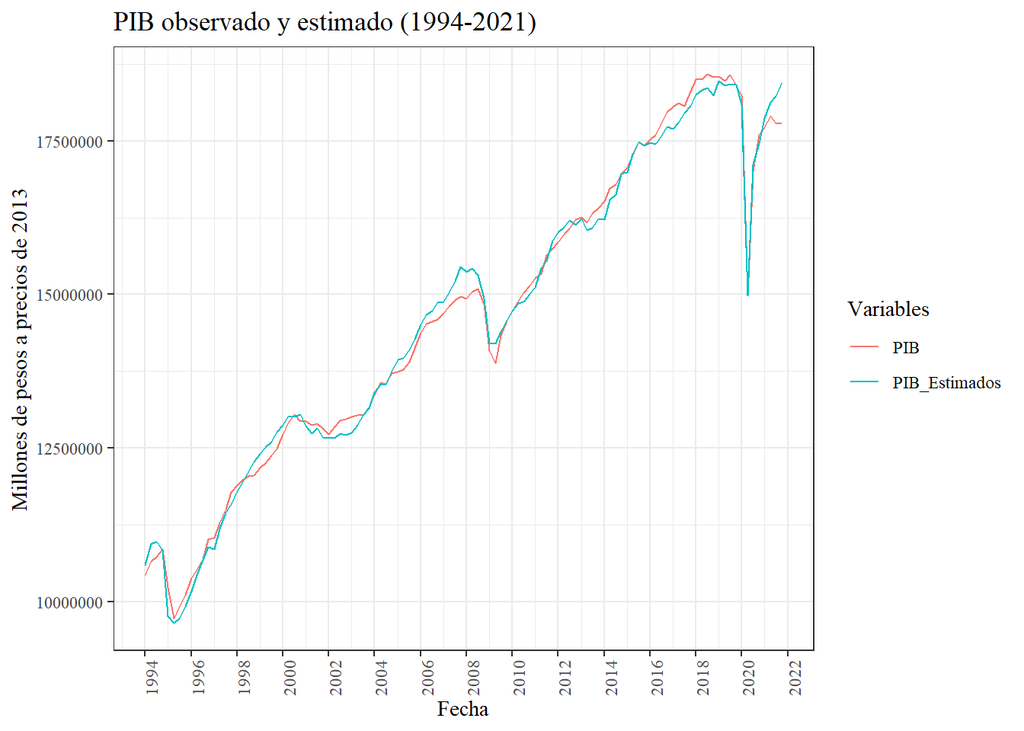

```r
m1_4_fitted <- Base1$PIB - residuals(m1_4)
m1_4_fitted2 <- m1_4$fitted.values
m1_4_fit <- cbind(m1_4_fitted, m1_4_fitted2)
View(m1_4_fit)

ggplot(Base1, aes(Periodo)) +
        geom_line(aes(y = PIB, color = "PIB")) +
        geom_line(aes(y = m1_4_fitted, color = "PIB_Estimados")) +
        labs(title = "PIB observado y estimado (1994-2021)",
          x = "Fecha",
          y = "Millones de pesos a precios de 2013",
          colour = "Variables") +
        theme_bw(base_family = "serif") +
        scale_x_date(date_breaks = "2 year", date_labels = "%Y") +
        theme(axis.text.x = element_text(angle = 90))
```

## 11.1 Pronósticos con base en supuestos de expectativas de expertos u organizaciones

Primero establecemos una nueva base llamada `Base1_m1_4` la cual contiene sólo las variables utilizadas en el modelo `m1_4`.

El siguiente paso es generar un dataframe que contenga los periodos para los que se generarán los pronósticos, lo nombramos como `amp`. Posteriormente, nombramos las variables del nuevo dataframe y le damos formato de fecha a la variable `Periodo` con el código `amp$Periodo <- yq(amp$Periodo)`, el cual indica que la variable tiene formato de año y trimestre. Después unimos los dataframes `Base1_m1_4` y `amp`.

```r
Base1_m1_4 <- Base1 %>%
  select(Periodo, PIB, FBKF_Priv, GDP_EUA, ficticia1)

amp <- data.frame(c("2022-1", "2022-2", "2022-3", "2022-4"),
                  c(NA, NA, NA, NA),
                  c(NA, NA, NA, NA),
                  c(NA, NA, NA, NA),
                  c(0, 0, 0, 0))

names(amp) <- c("Periodo", "PIB", "FBKF_Priv", "GDP_EUA", "ficticia1")

amp$Periodo <- yq(amp$Periodo)

Pronostico <- rbind(Base1_m1_4, amp)
```

Para los supuestos de expectativas de los expertos podemos utilizar la información de la [Encuesta sobre las Expectativas de los Especialistas en Economía del Sector Privado: Abril 2022](https://www.banxico.org.mx/publicaciones-y-prensa/encuestas-sobre-las-expectativas-de-los-especialis/%7BDF2FBFAC-67E1-F173-0839-DAA65AE58831%7D.pdf) del [Banco de México](https://www.banxico.org.mx/publicaciones-y-prensa/encuestas-sobre-las-expectativas-de-los-especialis/encuestas-expectativas-del-se.html). Esta encuesta provee el pronóstico de crecimiento para el PIB de Estados Unidos, que para 2022 presenta una estimación promedio de $3.17\%$ anual; y para la `FBKF_Priv` podemos suponer que crecerá de acuerdo a la media de la variación anual, que es de $2.6\%$.

Ahora, sustituimos los valores en el nuevo dataframe considerando los supuestos.

```r
Pronostico$FBKF_Priv[113] <- Pronostico$FBKF_Priv[109]*1.026
Pronostico$FBKF_Priv[114] <- Pronostico$FBKF_Priv[110]*1.026
Pronostico$FBKF_Priv[115] <- Pronostico$FBKF_Priv[111]*1.026
Pronostico$FBKF_Priv[116] <- Pronostico$FBKF_Priv[112]*1.026

Pronostico$GDP_EUA[113] <- Pronostico$GDP_EUA[109]*1.0317
Pronostico$GDP_EUA[114] <- Pronostico$GDP_EUA[110]*1.0317
Pronostico$GDP_EUA[115] <- Pronostico$GDP_EUA[111]*1.0317
Pronostico$GDP_EUA[116] <- Pronostico$GDP_EUA[112]*1.0317

tail(Pronostico, n = 8)
```

```
## # A tibble: 8 x 5
##   Periodo          PIB FBKF_Priv GDP_EUA ficticia1
##   <date>         <dbl>     <dbl>   <dbl>     <dbl>
## 1 2021-01-01 17722918.  2751331.  19056.         0
## 2 2021-04-01 17907744.  2778261.  19368.         0
## 3 2021-07-01 17782677.  2794524.  19479.         0
## 4 2021-10-01 17786344.  2792105.  19806.         0
## 5 2022-01-01       NA   2822866.  19660.         0
## 6 2022-04-01       NA   2850496.  19982.         0
## 7 2022-07-01       NA   2867182.  20096.         0
## 8 2022-10-01       NA   2864700.  20434.         0
```

Teniendo la información de las variables independientes podemos estimar los valores para la variable dependiente de la siguiente manera:

```r
M1_4 <- forecast(m1_4, newdata = Pronostico, h=4)
Pronostico$Pronostico_PIB <- M1_4$mean

Pronostico$PIB[113] <- Pronostico$Pronostico_PIB[113]
Pronostico$PIB[114] <- Pronostico$Pronostico_PIB[114]
Pronostico$PIB[115] <- Pronostico$Pronostico_PIB[115]
Pronostico$PIB[116] <- Pronostico$Pronostico_PIB[116]
```

Por último, graficamos el PIB con los valores pronosticados.

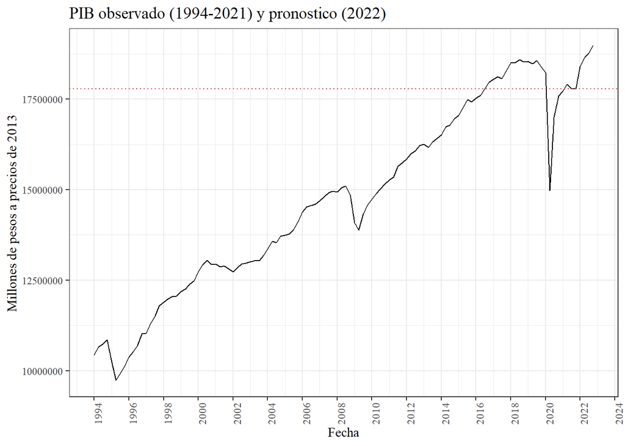

```r
ggplot(Pronostico, aes(Periodo, PIB)) +
  geom_line() +
  geom_hline(yintercept = 17786344, linetype = "dotted", color = "red") +
  labs(title = "PIB observado (1994-2021) y pronostico (2022)",
          x = "Fecha",
          y = "Millones de pesos a precios de 2013") +
        theme_bw(base_family = "serif") +
        scale_x_date(date_breaks = "2 year", date_labels = "%Y") +
        theme(axis.text.x = element_text(angle = 90))
```